## Coastal Bird monitoring at Boston Harbor Islands (BOHA)

Compiled on 2025-08-13 13:52:08.43065 by NETN using R version 4.4.2 (2024-10-31 ucrt)

### **Annual Gull and Cormorant Incubation Surveys**

#### Review Survey Effort in 2025

**Staff should evaluate the tables to ensure that at least one incubation survey was completed per year and that at least one survey was designated as the Primary Survey.**

Table 1. Number of unique observers conducting a Primary Incubation Survey in 2025 per date among Outer Islands. Confirm that at least one primary survey was conducted at all islands per date. Note that Shag Rocks and the Graves may not be surveyed due to the tidal stage.

| Island | Segment | Survey_Complete | Survey_Primary | 2025-05-12 | 2025-05-14 | 2025-05-24 |
| --- | --- | --- | --- | --- | --- | --- |
| Calf | East | Yes | Yes | 1 | 1 | 2 |
| Calf | West | Yes | Yes | 1 | 1 | 2 |
| Green | All | Yes | Yes | 1 | 1 | 1 |
| Little Brewster | All | Yes | Yes | 1 | 1 | 2 |
| Little Calf | All | Yes | Yes | 1 | 1 | 2 |
| Middle Brewster | North | Yes | Yes | 1 | 1 | 2 |
| Middle Brewster | South | Yes | Yes | 1 | 1 | 1 |
| Outer Brewster | All | Yes | Yes | 1 | 1 | 2 |
| Shag Rocks | All | Yes | Yes | 1 | 1 | 2 |
| The Graves | All | Yes | Yes | 1 | 1 | 1 |

Table 2. Number of unique observers conducting a Non_Primary Incubation Survey in 2025 per date among Outer Islands.

| Island | Segment | Survey_Complete | Survey_Primary | 2025-05-12 | 2025-05-14 | 2025-05-24 |
| --- | --- | --- | --- | --- | --- | --- |
| Calf | East | Yes | No | 1 | 1 | No Survey |
| Calf | West | Yes | No | 1 | 1 | No Survey |
| Green | All | Yes | No | 1 | 1 | 1 |
| Little Brewster | All | Yes | No | 1 | 1 | No Survey |
| Little Calf | All | Yes | No | 1 | 1 | No Survey |
| Middle Brewster | North | Yes | No | 1 | 1 | No Survey |
| Middle Brewster | South | Yes | No | 1 | 1 | 1 |
| Outer Brewster | All | Yes | No | 1 | 1 | No Survey |
| Shag Rocks | All | Yes | No | 1 | 1 | No Survey |
| The Graves | All | Yes | No | 1 | 1 | 1 |

Table 3. Total number of unique observers (primary and non-primary) by survey date during Incubation Surveys conducted among Outer Islands in 2025.

| Island | Segment | Survey_Complete | 2025-05-12 | 2025-05-14 | 2025-05-24 |
| --- | --- | --- | --- | --- | --- |
| Calf | East | Yes | 2 | 2 | 2 |
| Calf | West | Yes | 2 | 2 | 2 |
| Green | All | Yes | 2 | 2 | 2 |
| Little Brewster | All | Yes | 2 | 2 | 2 |
| Little Calf | All | Yes | 2 | 2 | 2 |
| Middle Brewster | North | Yes | 2 | 2 | 2 |
| Middle Brewster | South | Yes | 2 | 2 | 2 |
| Outer Brewster | All | Yes | 2 | 2 | 2 |
| Shag Rocks | All | Yes | 2 | 2 | 2 |
| The Graves | All | Yes | 2 | 2 | 2 |

The following sections summarize the annual and long term survey counts for cormorants and gulls surveyed during **boat-based Incubation surveys**. NETN staff should check the following sections of DCCO, GBBG, and HERG to ensure that:

**1. There is at least one completed primary survey (Survey_Complete = Yes) recorded for all island-segments in the database for each species and that the survey route (and count) was actually completed when you have records also denoting an incomplete survey was conducted on the same date.**

**2. There is consistency in the observer’s name denoted during the primary surveys for each Island-Segment and the entire Outer Island boat route for each day and among surveys counted on other days in the same year. For instance, in some years (e.g., 2024) there may be >1 completed survey for each island-segment on different dates. NETN staff should check to confirm with the field team whether the repeated surveys were conducted by the same observer(s) among dates if denoted otherwise in the database. If so, the initials of the Principal Investigator should be denoted for all Primary Survey records in the database.**

**3. All field observational notes (Obs_Notes) are clearly understood and the ramifications on the survey counts are reconciled in the database.**

**4. Incubating adult nest counts during the current year are reasonable compared to the long term record .**

**a. In a year when repeated primary surveys are conducted either by separate teams or on different dates, NETN staff should discuss variation in nest counts among events to determine whether one event should be considered primary over the other and whether calculating the average across the events represents the best possible estimate for nesting in that year.**

**b. NETN staff should examine graphical and tabular summaries of the long term survey record to assess whether the current year count is an outlier. See section: Nesting per island over time for each species.**

#### DCCO

##### Raw counts from current year 2025

Table 3. Current year counts of Double-crested Cormorant from primary surveys conducted among Outer Islands

| Island | Segment | Date | Survey_Complete | Nests | Observer | Obs_Notes |
| --- | --- | --- | --- | --- | --- | --- |
| Calf | East | 2025-05-12 | Yes | 0 | BCH | No notes recorded. |
| Calf | East | 2025-05-14 | Yes | 0 | RKC;BCH | No notes recorded. |
| Calf | East | 2025-05-24 | Yes | 0 | BCH | No notes recorded. |
| Calf | East | 2025-05-24 | Yes | 0 | MPH | No notes recorded. |
| Calf | West | 2025-05-12 | Yes | 111 | BCH | No notes recorded. |
| Calf | West | 2025-05-14 | Yes | 120 | BCH;RKC | No notes recorded. |
| Calf | West | 2025-05-24 | Yes | 126 | BCH | No notes recorded. |
| Calf | West | 2025-05-24 | Yes | 99 | MPH | No notes recorded. |
| Gallops | All | 2025-05-14 | Yes | 0 | BCH;RKC | No notes recorded. |
| Gallops | All | 2025-05-28 | Yes | 0 | BCH | No notes recorded. |
| Gallops | All | 2025-05-30 | Yes | 0 | BCH | No notes recorded. |
| Green | All | 2025-05-12 | Yes | 179 | BCH | No notes recorded. |
| Green | All | 2025-05-14 | Yes | 167 | BCH;RKC | No notes recorded. |
| Green | All | 2025-05-24 | Yes | 139 | BCH | No notes recorded. |
| Hangman | All | 2025-05-28 | Yes | 0 | BCH | No notes recorded. |
| Hangman | All | 2025-05-30 | Yes | 0 | BCH | No notes recorded. |
| Little Brewster | All | 2025-05-12 | Yes | 0 | BCH | No notes recorded. |
| Little Brewster | All | 2025-05-14 | Yes | 0 | RKC | No notes recorded. |
| Little Brewster | All | 2025-05-24 | Yes | 0 | BCH | No notes recorded. |
| Little Brewster | All | 2025-05-24 | Yes | 0 | MPH | No notes recorded. |
| Little Calf | All | 2025-05-12 | Yes | 135 | BCH | No notes recorded. |
| Little Calf | All | 2025-05-14 | Yes | 172 | BCH;RKC | No notes recorded. |
| Little Calf | All | 2025-05-24 | Yes | 170 | BCH | No notes recorded. |
| Little Calf | All | 2025-05-24 | Yes | 187 | MPH | Chicks observed |
| Middle Brewster | North | 2025-05-12 | Yes | 381 | BCH | No notes recorded. |
| Middle Brewster | North | 2025-05-14 | Yes | 325 | RKC | No notes recorded. |
| Middle Brewster | North | 2025-05-24 | Yes | 319 | BCH | No notes recorded. |
| Middle Brewster | North | 2025-05-24 | Yes | 270 | MPH | Chicks observed; more nests behind rock |
| Middle Brewster | South | 2025-05-12 | Yes | 307 | BCH | No notes recorded. |
| Middle Brewster | South | 2025-05-14 | Yes | 273 | RKC | No notes recorded. |
| Middle Brewster | South | 2025-05-24 | Yes | 264 | BCH | No notes recorded. |
| Outer Brewster | All | 2025-05-12 | Yes | 176 | BCH | No notes recorded. |
| Outer Brewster | All | 2025-05-14 | Yes | 133 | RKC | No notes recorded. |
| Outer Brewster | All | 2025-05-24 | Yes | 171 | BCH | No notes recorded. |
| Outer Brewster | All | 2025-05-24 | Yes | 171 | MPH | No notes recorded. |
| Rainsford | All | 2025-05-14 | Yes | 0 | BCH;OAS;RKC;SAS | No notes recorded. |
| Rainsford | All | 2025-05-28 | Yes | 0 | BCH | No notes recorded. |
| Shag Rocks | All | 2025-05-12 | Yes | 183 | BCH | No notes recorded. |
| Shag Rocks | All | 2025-05-14 | Yes | 174 | BCH | No notes recorded. |
| Shag Rocks | All | 2025-05-24 | Yes | 175 | BCH | No notes recorded. |
| Shag Rocks | All | 2025-05-24 | Yes | 193 | MPH | No notes recorded. |
| Sheep | All | 2025-05-28 | Yes | 96 | BCH | No notes recorded. |
| Sheep | All | 2025-05-30 | Yes | 106 | SRS | No notes recorded. |
| Spectacle | All | 2025-05-28 | Yes | 0 | BCH | No notes recorded. |
| The Graves | All | 2025-05-12 | Yes | 0 | BCH | No notes recorded. |
| The Graves | All | 2025-05-14 | Yes | 0 | BCH;RKC | No notes recorded. |
| The Graves | All | 2025-05-24 | Yes | 0 | MPH | No notes recorded. |

##### Nesting per island over time

Table 4. Annual counts of Double-crested Cormorant

| Island | 2007 | 2008 | 2009 | 2010 | 2012 | 2013 | 2014 | 2016 | 2017 | 2018 | 2019 | 2020 | 2021 | 2022 | 2023 | 2024 | 2025 |
| --- | --- | --- | --- | --- | --- | --- | --- | --- | --- | --- | --- | --- | --- | --- | --- | --- | --- |
| All Islands | 1198 | 1251 | 1321 | 1265 | 1181 | 1044 | 1062 | 992 | 1068 | 995 | 1174 | 1020 | 1286 | 1230 | 1246 | 1176 | 1391 |
| Calf | 153 | 111 | 58 | 70 | 65 | 43 | 19 | 8 | 16 | 69 | 34 | 40 | 48 | 123 | 111 | 124 | 114 |
| Green | 146 | 92 | 84 | 125 | 175 | 212 | 124 | 177 | 152 | 113 | 149 | 148 | 160 | 129 | 150 | 148 | 162 |
| Little Calf | 183 | 231 | 248 | 190 | 147 | 107 | 160 | 121 | 131 | 124 | 192 | 146 | 196 | 141 | 164 | 119 | 166 |
| Middle Brewster | 530 | 564 | 702 | 620 | 612 | 493 | 552 | 490 | 575 | 517 | 596 | 536 | 681 | 598 | 570 | 546 | 605 |
| Outer Brewster | 63 | 89 | 72 | 76 | 64 | 96 | 84 | 92 | 107 | 70 | 107 | 78 | 86 | 101 | 108 | 136 | 163 |
| Shag Rocks | 123 | 164 | 157 | 184 | 118 | 93 | 123 | 104 | 87 | 102 | 96 | 72 | 115 | 138 | 143 | 103 | 181 |
| Spinnaker |  |  |  |  |  |  |  |  |  |  |  |  |  |  |  | 0 |  |

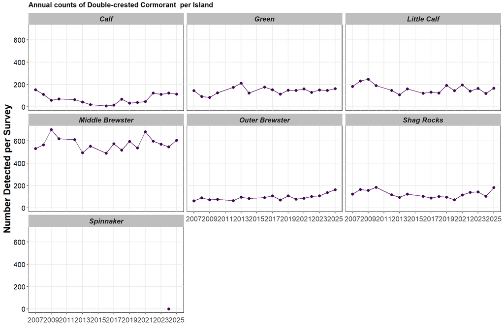

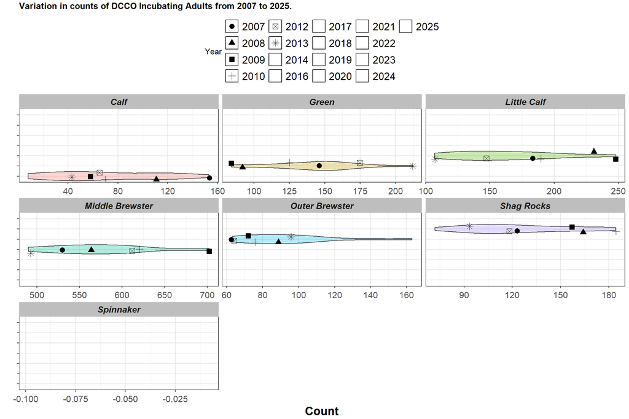

#### GBBG

##### Raw counts from current year 2025

Table 5. Current year counts of Great black-backed Gulls from primary survey

| Island | Segment | Date | Survey_Complete | Nests | Observer | Obs_Notes |
| --- | --- | --- | --- | --- | --- | --- |
| Calf | East | 2025-05-12 | Yes | 10 | BCH | No notes recorded. |
| Calf | East | 2025-05-14 | Yes | 7 | RKC;BCH | No notes recorded. |
| Calf | East | 2025-05-24 | Yes | 11 | BCH | No notes recorded. |
| Calf | East | 2025-05-24 | Yes | 13 | MPH | No notes recorded. |
| Calf | West | 2025-05-12 | Yes | 11 | BCH | No notes recorded. |
| Calf | West | 2025-05-14 | Yes | 18 | BCH;RKC | No notes recorded. |
| Calf | West | 2025-05-24 | Yes | 9 | BCH | No notes recorded. |
| Calf | West | 2025-05-24 | Yes | 9 | MPH | No notes recorded. |
| Gallops | All | 2025-05-14 | Yes | 27 | BCH;RKC | No notes recorded. |
| Gallops | All | 2025-05-28 | Yes | 16 | BCH | No notes recorded. |
| Gallops | All | 2025-05-30 | Yes | 18 | BCH | Chicks observed (two nests) |
| Green | All | 2025-05-12 | Yes | 7 | BCH | No notes recorded. |
| Green | All | 2025-05-14 | Yes | 18 | BCH;RKC | No notes recorded. |
| Green | All | 2025-05-24 | Yes | 12 | BCH | No notes recorded. |
| Hangman | All | 2025-05-28 | Yes | 26 | BCH | One nest on offshore rock; two mainland nests hatched |
| Hangman | All | 2025-05-30 | Yes | 10 | BCH | Three nests have hatched |
| Little Brewster | All | 2025-05-12 | Yes | 2 | BCH | No notes recorded. |
| Little Brewster | All | 2025-05-14 | Yes | 7 | RKC | No notes recorded. |
| Little Brewster | All | 2025-05-24 | Yes | 6 | BCH | No notes recorded. |
| Little Brewster | All | 2025-05-24 | Yes | 4 | MPH | No notes recorded. |
| Little Calf | All | 2025-05-12 | Yes | 7 | BCH | No notes recorded. |
| Little Calf | All | 2025-05-14 | Yes | 7 | BCH;RKC | No notes recorded. |
| Little Calf | All | 2025-05-24 | Yes | 24 | BCH | No notes recorded. |
| Little Calf | All | 2025-05-24 | Yes | 3 | MPH | No notes recorded. |
| Middle Brewster | North | 2025-05-12 | Yes | 6 | BCH | No notes recorded. |
| Middle Brewster | North | 2025-05-14 | Yes | 5 | RKC | No notes recorded. |
| Middle Brewster | North | 2025-05-24 | Yes | 5 | BCH | No notes recorded. |
| Middle Brewster | North | 2025-05-24 | Yes | 7 | MPH | No notes recorded. |
| Middle Brewster | South | 2025-05-12 | Yes | 0 | BCH | No notes recorded. |
| Middle Brewster | South | 2025-05-14 | Yes | 4 | RKC | No notes recorded. |
| Middle Brewster | South | 2025-05-24 | Yes | 5 | BCH | No notes recorded. |
| Outer Brewster | All | 2025-05-12 | Yes | 24 | BCH | No notes recorded. |
| Outer Brewster | All | 2025-05-14 | Yes | 30 | RKC | No notes recorded. |
| Outer Brewster | All | 2025-05-24 | Yes | 20 | BCH | No notes recorded. |
| Outer Brewster | All | 2025-05-24 | Yes | 22 | MPH | No notes recorded. |
| Rainsford | All | 2025-05-14 | Yes | 3 | BCH;OAS;RKC;SAS | Two NW; one SW |
| Rainsford | All | 2025-05-28 | Yes | 2 | BCH | Third nest not being incubated, but adults nearby…hatched? |
| Shag Rocks | All | 2025-05-12 | Yes | 2 | BCH | No notes recorded. |
| Shag Rocks | All | 2025-05-14 | Yes | 3 | BCH | No notes recorded. |
| Shag Rocks | All | 2025-05-24 | Yes | 6 | BCH | No notes recorded. |
| Shag Rocks | All | 2025-05-24 | Yes | 5 | MPH | No notes recorded. |
| Sheep | All | 2025-05-28 | Yes | 9 | BCH | No notes recorded. |
| Sheep | All | 2025-05-30 | Yes | 12 | SRS | Chicks observed |
| Spectacle | All | 2025-05-28 | Yes | 0 | BCH | No notes recorded. |
| The Graves | All | 2025-05-12 | Yes | 0 | BCH | No notes recorded. |
| The Graves | All | 2025-05-14 | Yes | 0 | BCH;RKC | No notes recorded. |
| The Graves | All | 2025-05-24 | Yes | 0 | MPH | No notes recorded. |

##### Nesting per island over time

Table 6. Annual counts of Great Black-backed Gull

| Island | 2007 | 2008 | 2009 | 2010 | 2012 | 2013 | 2014 | 2016 | 2017 | 2018 | 2019 | 2020 | 2021 | 2022 | 2023 | 2024 | 2025 |
| --- | --- | --- | --- | --- | --- | --- | --- | --- | --- | --- | --- | --- | --- | --- | --- | --- | --- |
| All Islands | 146 | 82 | 99 | 66 | 46 | 88 | 73 | 91 | 88 | 105 | 88 | 85 | 103 | 100 | 69 | 64 | 81 |
| Calf | 23 | 18 | 16 | 17 | 12 | 17 | 29 | 22 | 25 | 22 | 20 | 23 | 22 | 17 | 14 | 10 | 22 |
| Green | 19 | 19 | 18 | 14 | 15 | 20 | 3 | 26 | 23 | 36 | 24 | 21 | 27 | 21 | 21 | 10 | 12 |
| Little Calf | 24 | 6 | 10 | 17 | 4 | 7 | 11 | 11 | 13 | 9 | 5 | 9 | 9 | 8 | 3 | 6 | 10 |
| Middle Brewster | 53 | 17 | 31 | 4 | 2 | 27 | 6 | 13 | 10 | 13 | 14 | 11 | 12 | 18 | 10 | 12 | 9 |
| Outer Brewster | 27 | 19 | 18 | 10 | 12 | 14 | 22 | 11 | 14 | 24 | 22 | 18 | 30 | 34 | 19 | 24 | 24 |
| Shag Rocks | 0 | 3 | 6 | 4 | 1 | 3 | 2 | 8 | 3 | 1 | 3 | 3 | 3 | 2 | 2 | 2 | 4 |
| Spinnaker |  |  |  |  |  |  |  |  |  |  |  |  |  |  |  | 0 |  |

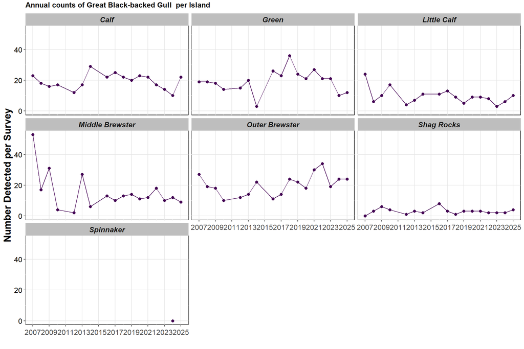

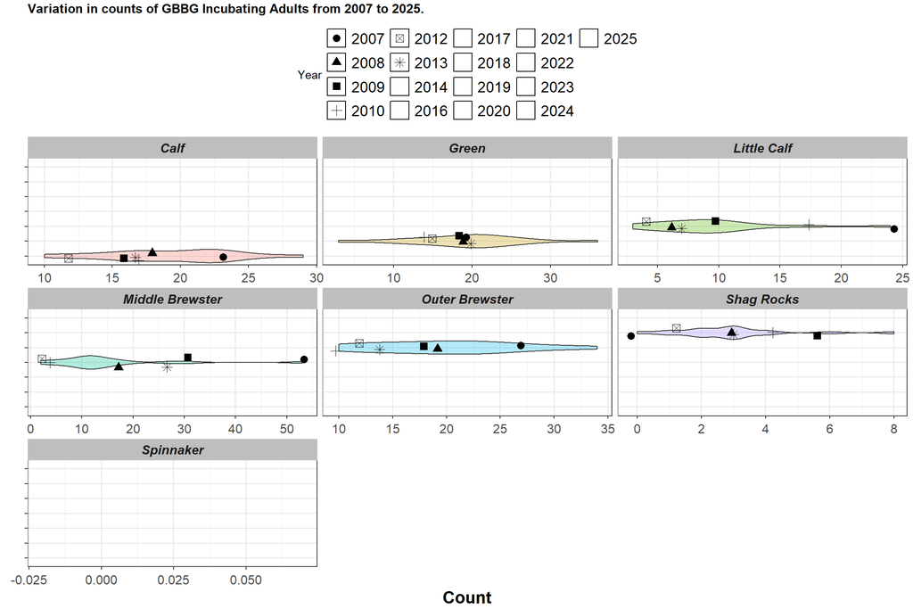

#### HERG

##### Raw counts from current year 2025

Table 7. Current year counts of Herring Gulls from primary survey

| Island | Segment | Date | Survey_Complete | Nests | Observer | Obs_Notes |
| --- | --- | --- | --- | --- | --- | --- |
| Calf | East | 2025-05-12 | Yes | 53 | BCH | No notes recorded. |
| Calf | East | 2025-05-14 | Yes | 56 | RKC;BCH | No notes recorded. |
| Calf | East | 2025-05-24 | Yes | 32 | BCH | No notes recorded. |
| Calf | East | 2025-05-24 | Yes | 40 | MPH | No notes recorded. |
| Calf | West | 2025-05-12 | Yes | 27 | BCH | No notes recorded. |
| Calf | West | 2025-05-14 | Yes | 23 | BCH;RKC | No notes recorded. |
| Calf | West | 2025-05-24 | Yes | 41 | BCH | No notes recorded. |
| Calf | West | 2025-05-24 | Yes | 24 | MPH | No notes recorded. |
| Gallops | All | 2025-05-14 | Yes | 3 | BCH;RKC | No notes recorded. |
| Gallops | All | 2025-05-28 | Yes | 0 | BCH | No notes recorded. |
| Gallops | All | 2025-05-30 | Yes | 1 | BCH | No notes recorded. |
| Green | All | 2025-05-12 | Yes | 21 | BCH | No notes recorded. |
| Green | All | 2025-05-14 | Yes | 17 | BCH;RKC | No notes recorded. |
| Green | All | 2025-05-24 | Yes | 11 | BCH | No notes recorded. |
| Hangman | All | 2025-05-28 | Yes | 0 | BCH | No notes recorded. |
| Hangman | All | 2025-05-30 | Yes | 2 | BCH | No notes recorded. |
| Little Brewster | All | 2025-05-12 | Yes | 11 | BCH | No notes recorded. |
| Little Brewster | All | 2025-05-14 | Yes | 18 | RKC | HERG copulation also observed (1) |
| Little Brewster | All | 2025-05-24 | Yes | 24 | BCH | No notes recorded. |
| Little Brewster | All | 2025-05-24 | Yes | 22 | MPH | No notes recorded. |
| Little Calf | All | 2025-05-12 | Yes | 15 | BCH | No notes recorded. |
| Little Calf | All | 2025-05-14 | Yes | 13 | BCH;RKC | No notes recorded. |
| Little Calf | All | 2025-05-24 | Yes | 41 | BCH | No notes recorded. |
| Little Calf | All | 2025-05-24 | Yes | 16 | MPH | No notes recorded. |
| Middle Brewster | North | 2025-05-12 | Yes | 29 | BCH | No notes recorded. |
| Middle Brewster | North | 2025-05-14 | Yes | 22 | RKC | No notes recorded. |
| Middle Brewster | North | 2025-05-24 | Yes | 39 | BCH | No notes recorded. |
| Middle Brewster | North | 2025-05-24 | Yes | 36 | MPH | No notes recorded. |
| Middle Brewster | South | 2025-05-12 | Yes | 33 | BCH | No notes recorded. |
| Middle Brewster | South | 2025-05-14 | Yes | 62 | RKC | No notes recorded. |
| Middle Brewster | South | 2025-05-24 | Yes | 53 | BCH | No notes recorded. |
| Outer Brewster | All | 2025-05-12 | Yes | 103 | BCH | No notes recorded. |
| Outer Brewster | All | 2025-05-14 | Yes | 76 | RKC | No notes recorded. |
| Outer Brewster | All | 2025-05-24 | Yes | 70 | BCH | No notes recorded. |
| Outer Brewster | All | 2025-05-24 | Yes | 94 | MPH | No notes recorded. |
| Rainsford | All | 2025-05-14 | Yes | 0 | BCH;OAS;RKC;SAS | No notes recorded. |
| Rainsford | All | 2025-05-28 | Yes | 0 | BCH | No notes recorded. |
| Shag Rocks | All | 2025-05-12 | Yes | 0 | BCH | No notes recorded. |
| Shag Rocks | All | 2025-05-14 | Yes | 0 | BCH | No notes recorded. |
| Shag Rocks | All | 2025-05-24 | Yes | 1 | BCH | No notes recorded. |
| Shag Rocks | All | 2025-05-24 | Yes | 0 | MPH | No notes recorded. |
| Sheep | All | 2025-05-28 | Yes | 36 | BCH | No notes recorded. |
| Sheep | All | 2025-05-30 | Yes | 45 | SRS | No notes recorded. |
| Spectacle | All | 2025-05-28 | Yes | 0 | BCH | No notes recorded. |
| The Graves | All | 2025-05-12 | Yes | 0 | BCH | No notes recorded. |
| The Graves | All | 2025-05-14 | Yes | 0 | BCH;RKC | No notes recorded. |
| The Graves | All | 2025-05-24 | Yes | 0 | MPH | No notes recorded. |

##### Nesting per island over time

Table 8. Annual counts of Herring Gull

| Island | 2007 | 2008 | 2009 | 2010 | 2012 | 2013 | 2014 | 2016 | 2017 | 2018 | 2019 | 2020 | 2021 | 2022 | 2023 | 2024 | 2025 |
| --- | --- | --- | --- | --- | --- | --- | --- | --- | --- | --- | --- | --- | --- | --- | --- | --- | --- |
| All Islands | 295 | 378 | 324 | 255 | 182 | 397 | 428 | 346 | 410 | 437 | 439 | 364 | 334 | 411 | 302 | 424 | 278 |
| Calf | 58 | 118 | 74 | 62 | 60 | 102 | 122 | 92 | 99 | 115 | 126 | 78 | 101 | 87 | 94 | 104 | 74 |
| Green | 21 | 29 | 24 | 20 | 5 | 27 | 24 | 24 | 23 | 25 | 26 | 44 | 19 | 25 | 22 | 36 | 16 |
| Little Calf | 45 | 13 | 6 | 7 | 2 | 10 | 12 | 14 | 8 | 8 | 15 | 9 | 7 | 6 | 7 | 10 | 21 |
| Middle Brewster | 44 | 80 | 115 | 72 | 38 | 99 | 112 | 85 | 105 | 123 | 107 | 97 | 88 | 118 | 83 | 94 | 81 |
| Outer Brewster | 127 | 138 | 104 | 92 | 76 | 159 | 158 | 131 | 175 | 164 | 165 | 136 | 118 | 175 | 95 | 178 | 86 |
| Shag Rocks | 0 | 0 | 1 | 2 | 1 | 0 | 0 | 0 | 0 | 2 | 0 | 0 | 1 | 0 | 1 | 2 | 0 |
| Spinnaker |  |  |  |  |  |  |  |  |  |  |  |  |  |  |  | 0 |  |

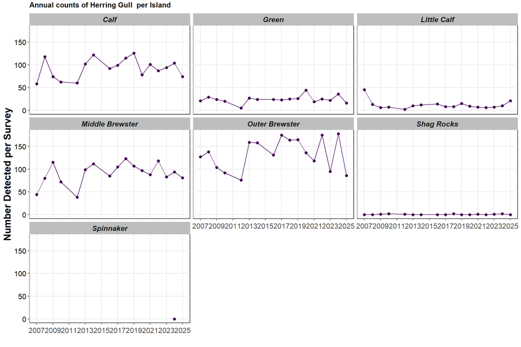

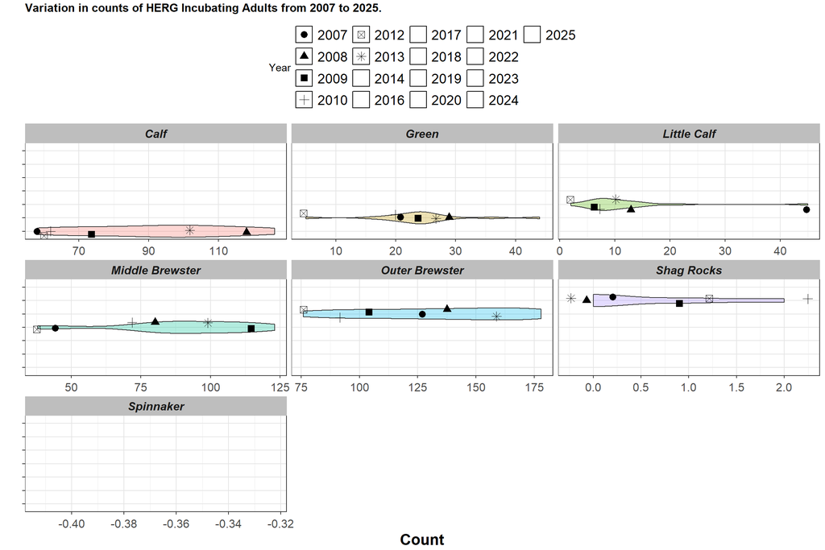

### **Annual COEI Creche Surveys**

The following tables and graphs summarize data from boat-based creche surveys in the program’s database conducted in 2025.

#### Review Survey Effort in 2025

**NETN staff should evaluate the below tables for accuracy and completeness to ensure that (1) at least one creche survey was completed per year during the peak season, (2) evaluate, document and reconcile why there may be incomplete surveys denoted as a primary survey for a particular date, (3) assess that data for all four life stages were collected at each Island-Segment and Date, and (5) confirm that at least one survey was designated as the Primary Survey per date.**

Table 9. Number of unique observers conducting creche surveys by date in 2025. Empty cells denote that no survey was conducted meeting the table criteria. At least one observer should be denoted for completed surveys per Survey_Primary event.

| Island | Segment | Survey_Complete | Survey_Primary | 2025-06-05 | 2025-06-11 | 2025-06-18 | 2025-06-25 | 2025-07-01 | 2025-07-09 |
| --- | --- | --- | --- | --- | --- | --- | --- | --- | --- |
| Calf | East | Yes | No | 1 | 1 |  |  |  |  |
| Calf | East | Yes | Yes | 1 | 1 | 1 | 1 | 1 | 1 |
| Calf | West | Yes | No | 1 | 1 |  |  |  |  |
| Calf | West | Yes | Yes | 1 | 1 | 1 | 1 | 1 | 1 |
| Green | All | Yes | No | 1 | 1 |  |  |  |  |
| Green | All | Yes | Yes | 1 | 1 | 1 | 1 | 1 | 1 |
| Little Brewster | All | Yes | No | 1 | 1 |  |  |  |  |
| Little Brewster | All | Yes | Yes | 1 | 1 | 1 | 1 | 1 | 1 |
| Little Calf | All | Yes | No | 1 | 1 |  |  |  |  |
| Little Calf | All | Yes | Yes | 1 | 1 | 1 | 1 | 1 | 1 |
| Middle Brewster | North | Yes | No |  | 1 |  |  |  |  |
| Middle Brewster | North | Yes | Yes | 2 | 1 | 1 | 1 | 1 | 1 |
| Middle Brewster | South | Yes | No | 1 | 1 |  |  |  |  |
| Middle Brewster | South | Yes | Yes | 1 | 1 | 1 | 1 | 1 | 1 |
| Outer Brewster | All | Yes | No | 1 | 1 |  |  |  |  |
| Outer Brewster | All | Yes | Yes | 1 | 1 | 1 | 1 | 1 | 1 |
| Roaring Bulls | All | Yes | Yes |  |  |  | 1 |  | 1 |
| Shag Rocks | All | Yes | No | 1 | 1 |  |  |  |  |
| Shag Rocks | All | Yes | Yes | 1 | 1 | 1 | 1 | 1 | 1 |
| The Graves | All | Yes | No |  | 1 |  |  |  |  |
| The Graves | All | Yes | Yes | 2 | 1 | 1 | 1 | 1 | 1 |

Table 10. Number of life stages counted during creche surveys by date in 2025. Empty cells either denote that no survey was conducted or that the survey was incomplete. Four life stages should be monitored per event.

| Island | Segment | 2025-06-05 | 2025-06-11 | 2025-06-18 | 2025-06-25 | 2025-07-01 | 2025-07-09 |
| --- | --- | --- | --- | --- | --- | --- | --- |
| Calf | East | 8 | 8 | 4 | 4 | 4 | 4 |
| Calf | West | 8 | 8 | 4 | 4 | 4 | 4 |
| Green | All | 8 | 8 | 4 | 4 | 4 | 4 |
| Little Brewster | All | 8 | 8 | 4 | 4 | 4 | 4 |
| Little Calf | All | 8 | 8 | 4 | 4 | 4 | 4 |
| Middle Brewster | North | 4 | 8 | 4 | 4 | 4 | 4 |
| Middle Brewster | South | 8 | 8 | 4 | 4 | 4 | 4 |
| Outer Brewster | All | 8 | 8 | 4 | 4 | 4 | 4 |
| Roaring Bulls | All |  |  |  | 4 |  | 4 |
| Shag Rocks | All | 8 | 8 | 4 | 4 | 4 | 4 |
| The Graves | All | 4 | 8 | 4 | 4 | 4 | 4 |

Table 11. Details from records listed as the Primary Survey but also as Incomplete

[output not shown]

##### Current year (2025) surveys by date

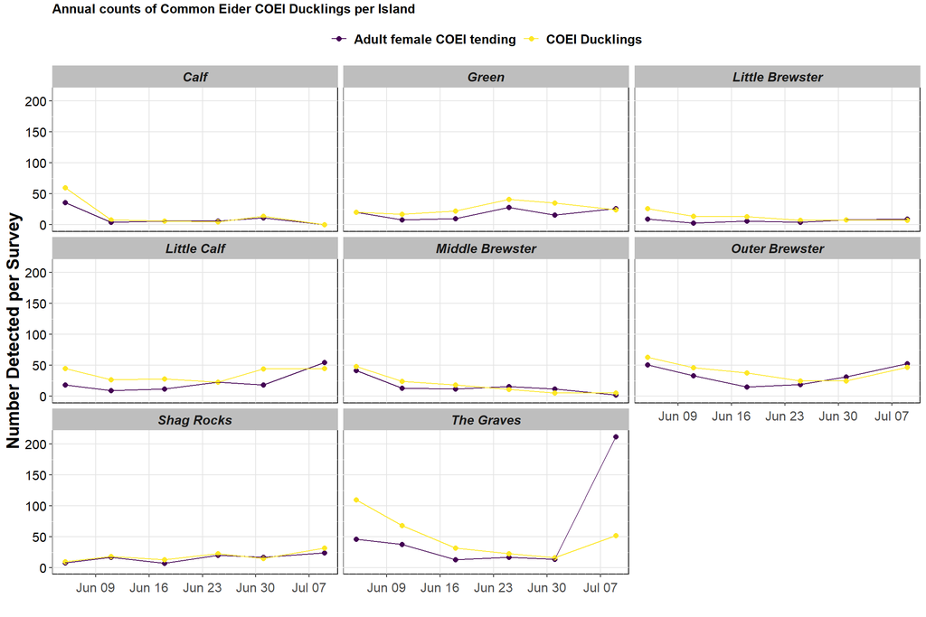

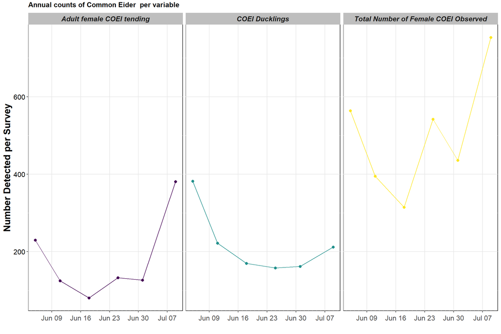

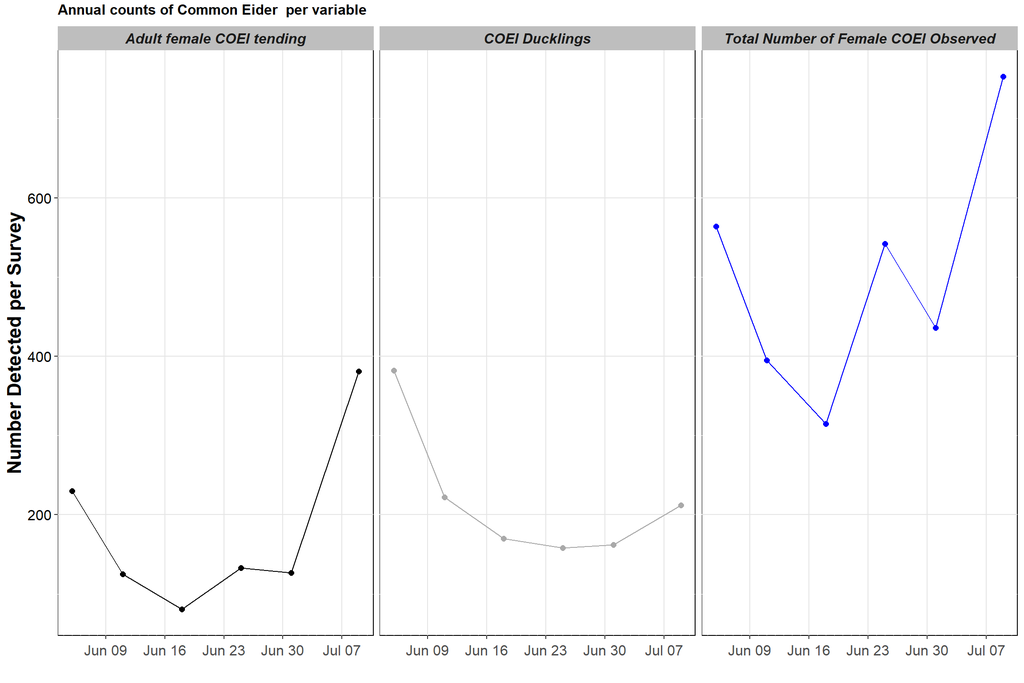

Table 12. Counts per life stage of Common Eider during creche surveys in 2025

| Island | variable | 2025-06-05 | 2025-06-11 | 2025-06-18 | 2025-06-25 | 2025-07-01 | 2025-07-09 |
| --- | --- | --- | --- | --- | --- | --- | --- |
| Calf | AdltfmlCOEIt | 36 | 4 | 6 | 6 | 11 | 0 |
| Calf | COEIDucklngs | 60 | 8 | 6 | 5 | 14 | 0 |
| Green | AdltfmlCOEIt | 20 | 8 | 10 | 28 | 16 | 26 |
| Green | COEIDucklngs | 20 | 17 | 22 | 41 | 35 | 24 |
| Little Brewster | AdltfmlCOEIt | 9 | 3 | 6 | 4 | 8 | 9 |
| Little Brewster | COEIDucklngs | 26 | 14 | 13 | 7 | 8 | 7 |
| Little Calf | AdltfmlCOEIt | 18 | 9 | 12 | 23 | 18 | 55 |
| Little Calf | COEIDucklngs | 45 | 27 | 28 | 23 | 44 | 45 |
| Middle Brewster | AdltfmlCOEIt | 42 | 13 | 12 | 16 | 12 | 2 |
| Middle Brewster | COEIDucklngs | 48 | 24 | 18 | 11 | 5 | 5 |
| Outer Brewster | AdltfmlCOEIt | 51 | 33 | 15 | 19 | 31 | 53 |
| Outer Brewster | COEIDucklngs | 63 | 46 | 38 | 25 | 25 | 47 |
| Shag Rocks | AdltfmlCOEIt | 8 | 17 | 7 | 20 | 17 | 24 |
| Shag Rocks | COEIDucklngs | 10 | 18 | 13 | 23 | 15 | 32 |
| The Graves | AdltfmlCOEIt | 46 | 38 | 13 | 17 | 14 | 212 |
| The Graves | COEIDucklngs | 110 | 68 | 32 | 23 | 16 | 52 |

#### Annual counts over time by life stage

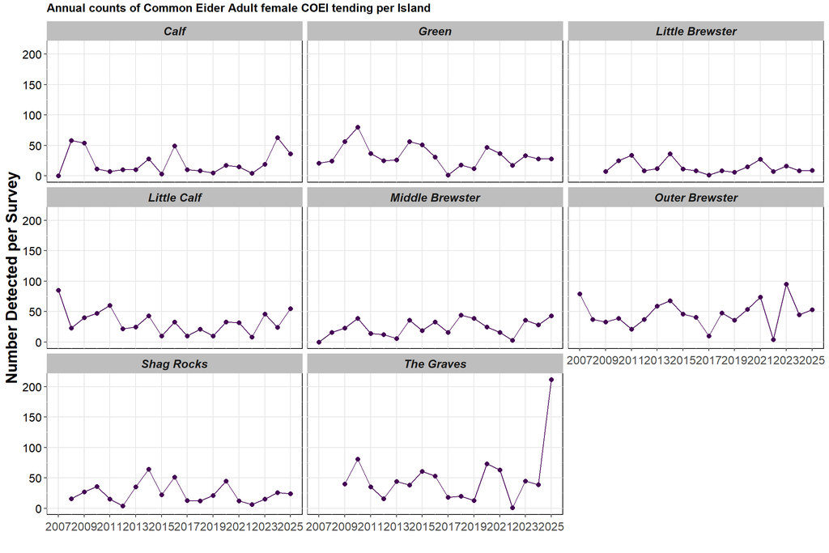

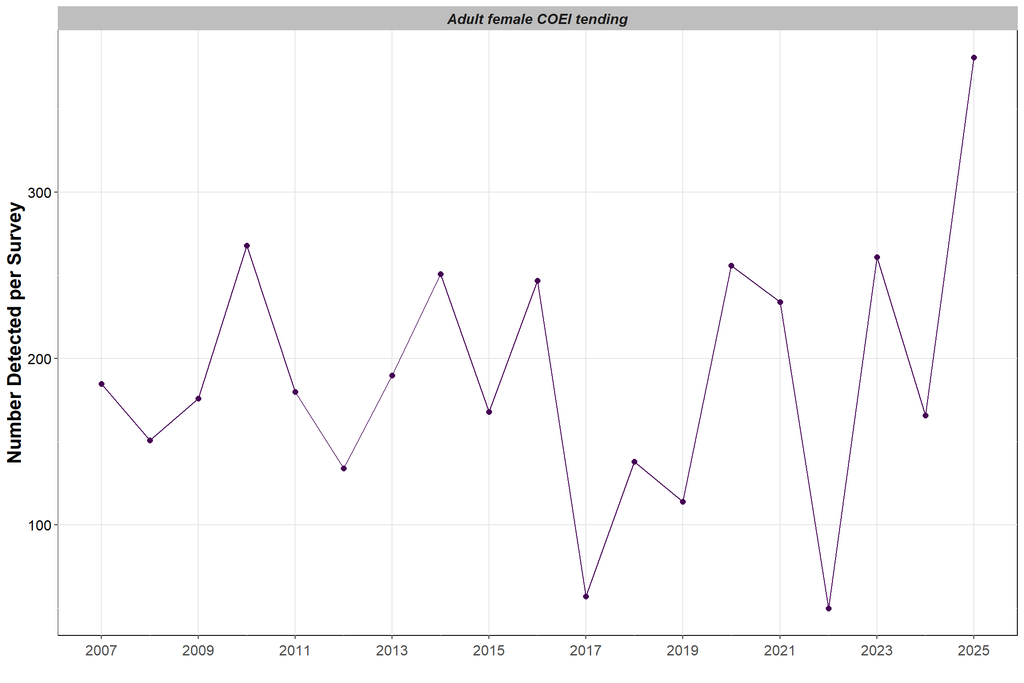

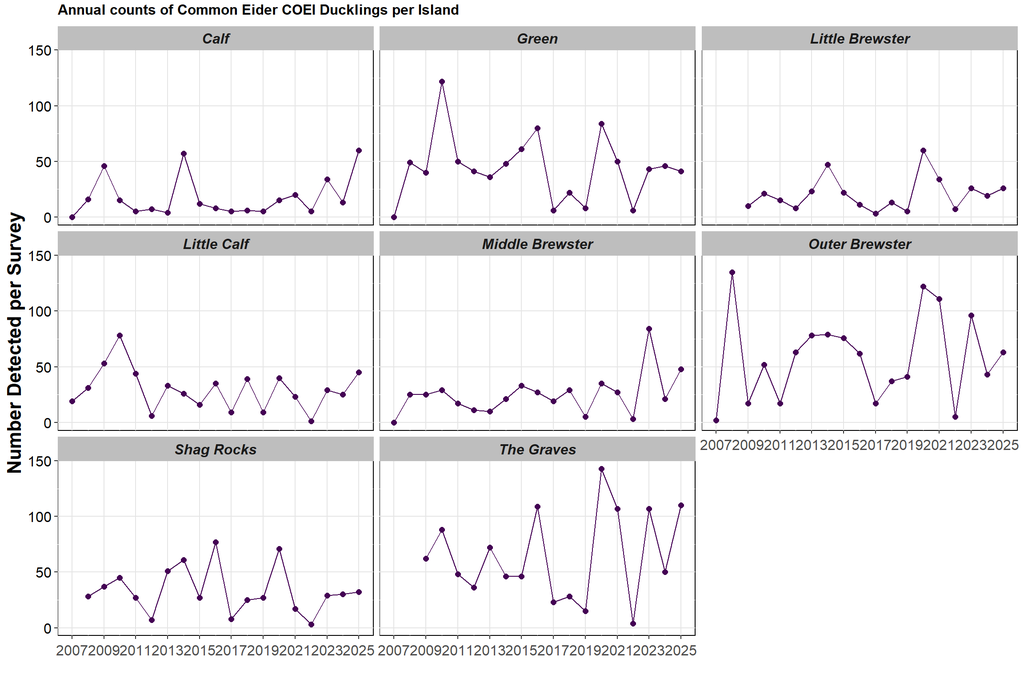

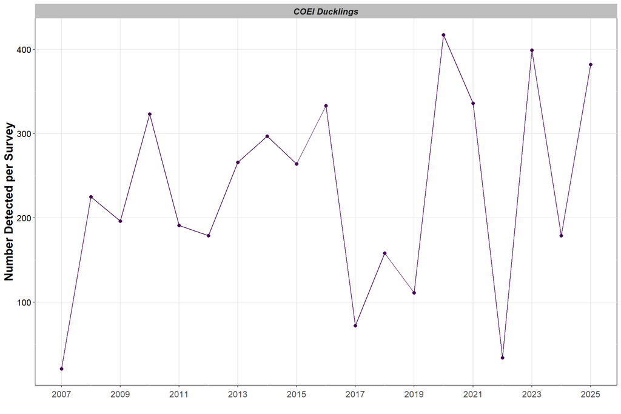

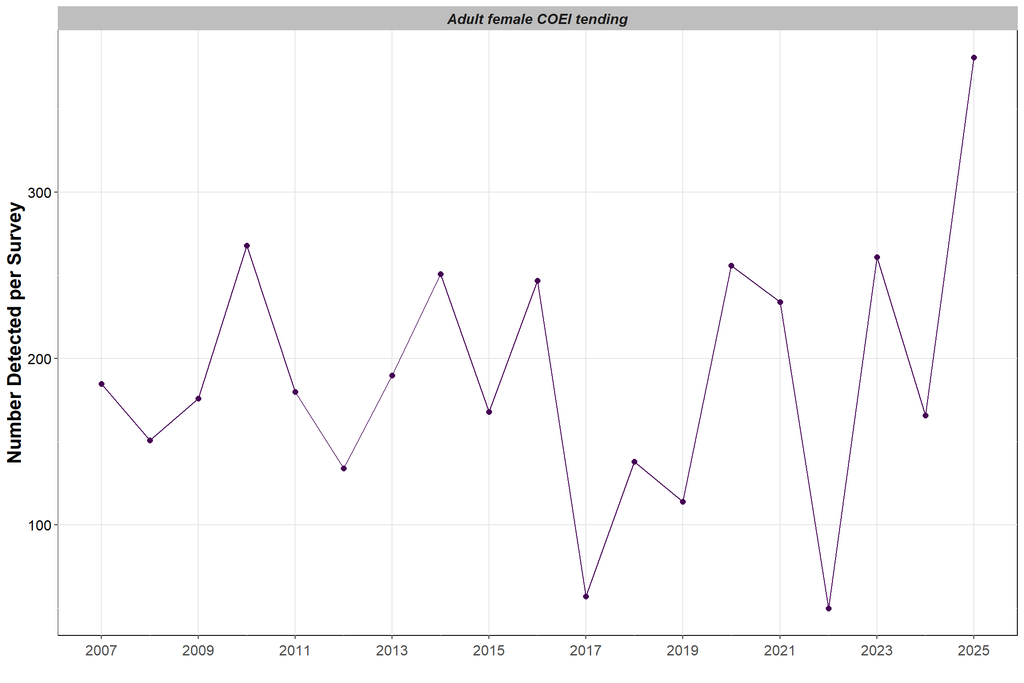

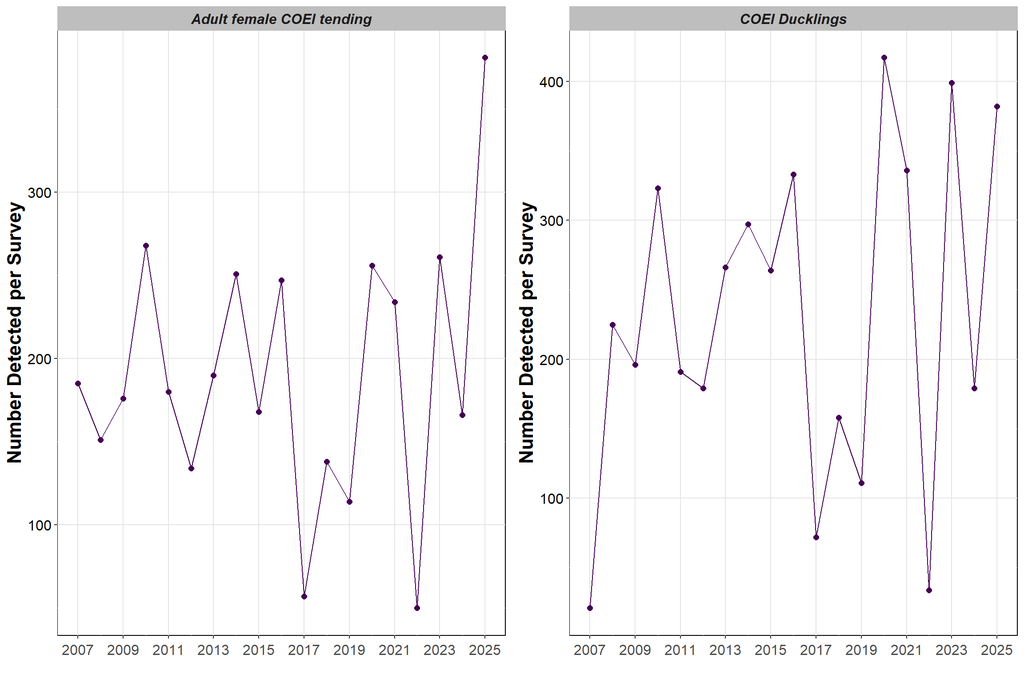

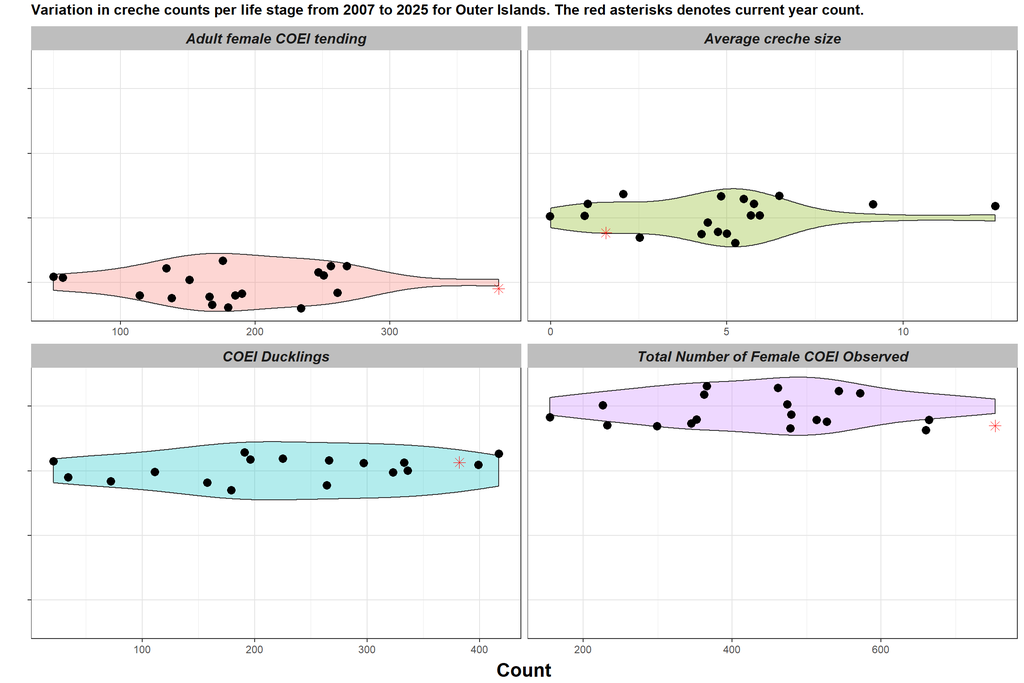

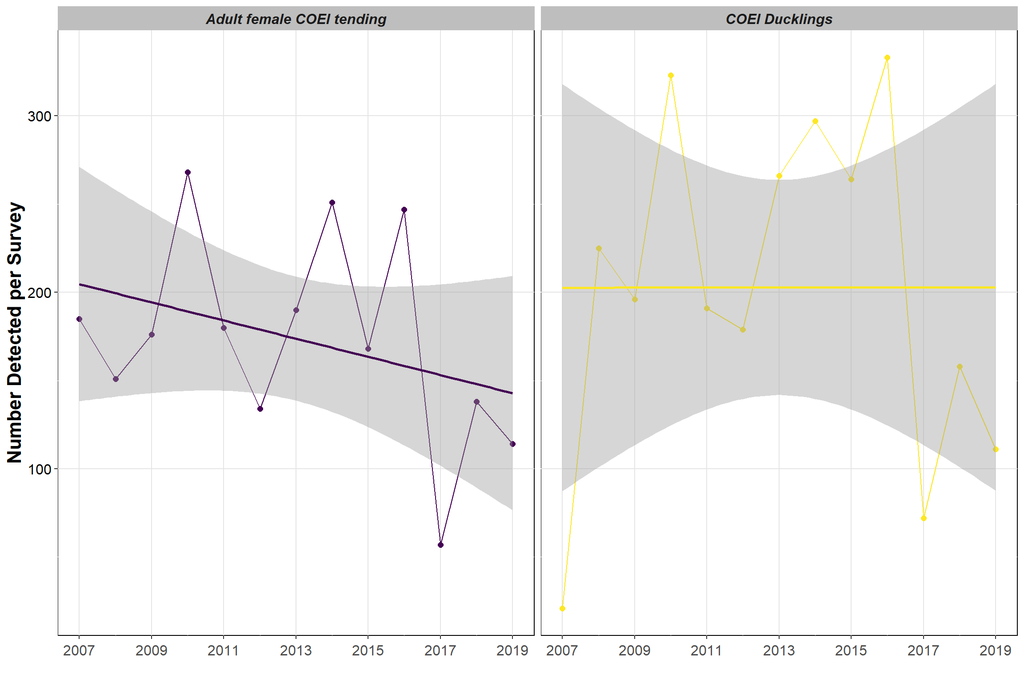

Call: lm(formula = value ~ year, data = filter(creche_y, variable == “COEI Ducklings”), offset = Survey_Size)

Residuals: Min 1Q Median 3Q Max -89.35 -59.15 -43.85 -5.59 1885.55

Coefficients: Estimate Std. Error t value Pr(>|t|) (Intercept) -3764.477 2343.745 -1.606 0.109 year 1.900 1.162 1.635 0.103

Residual standard error: 160.2 on 662 degrees of freedom Multiple R-squared: 0.004022, Adjusted R-squared: 0.002517 F-statistic: 2.673 on 1 and 662 DF, p-value: 0.1025

Call: lm(formula = value ~ year, data = filter(creche_y, variable == “Adult female COEI tending”), offset = Survey_Size)

Residuals: Min 1Q Median 3Q Max -69.18 -47.36 -33.67 -3.21 1117.04

Coefficients: Estimate Std. Error t value Pr(>|t|) (Intercept) -1164.0024 1708.2091 -0.681 0.496 year 0.6038 0.8472 0.713 0.476

Residual standard error: 116.8 on 662 degrees of freedom Multiple R-squared: 0.0007666, Adjusted R-squared: -0.0007428 F-statistic: 0.5079 on 1 and 662 DF, p-value: 0.4763

### **Ground-based Nest Surveys**

**NETN staff should evaluate the below tables for accuracy and completeness to ensure that (1) at least one ground survey was completed during the peak season for all appropriate Island-Segments (see protocol), (2) evaluate, document and reconcile why there may be incomplete surveys denoted as a primary survey for a particular date, (3) confirm that at least one survey was designated as the Primary Survey for each species and per date, and (4) evaluate what proportion of surveys conducted direct vs indirect (flush) counting methods.**

#### Review Survey Effort in 2025

[1] “No ground-based nest surveys were collected during 2025”

Notes:

1. It may be useful to bring in the full table of islands that were supposed to be surveyed to check completeness of surveying work
2. Double check that partial surveys occurred and that the portion of the route survey was estimated in the DB. As of now the % surveyed is not being imported into the R package object (confirm data field with Adam).

#### **Common Eider (*Somateria mollissima*)**

##### Current year (2025)

[1] “No ground-based nest surveys were collected during 2025”

##### Counts over time

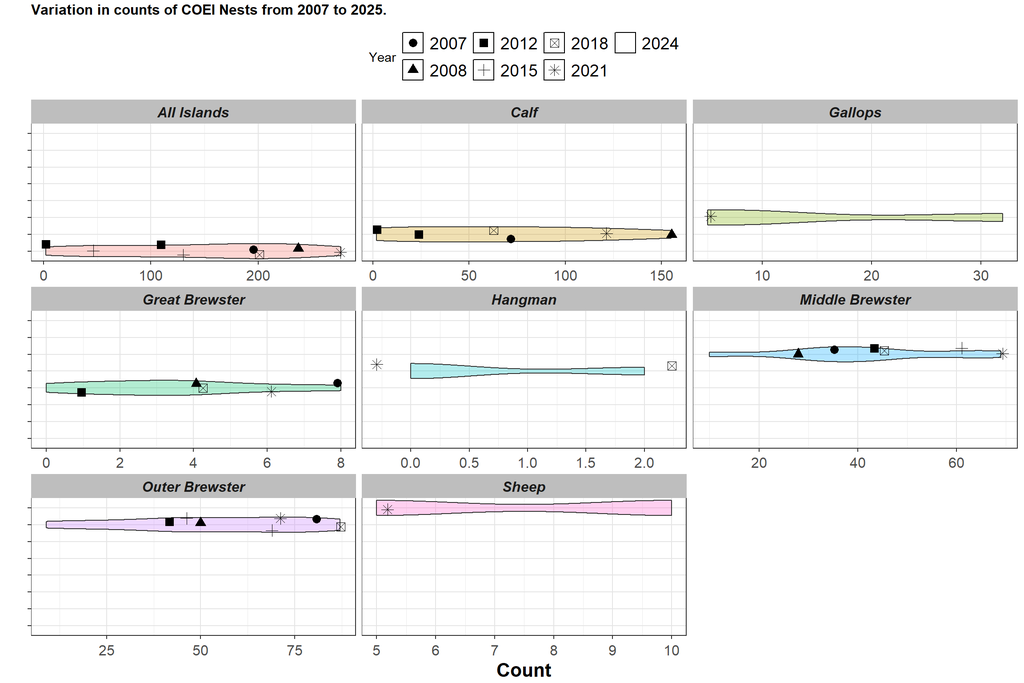

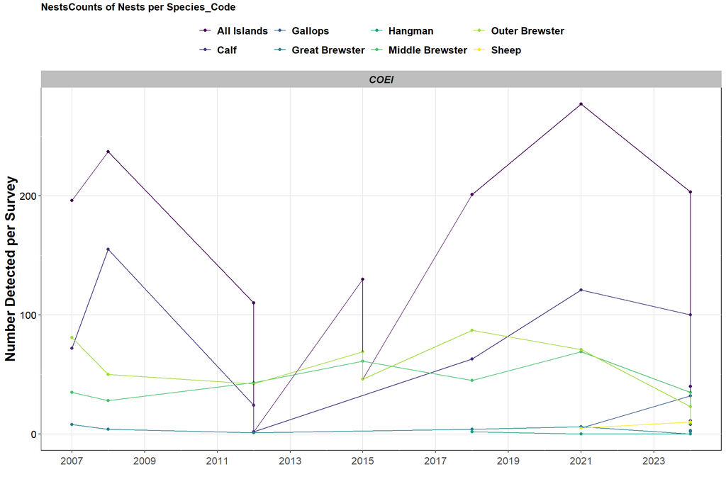

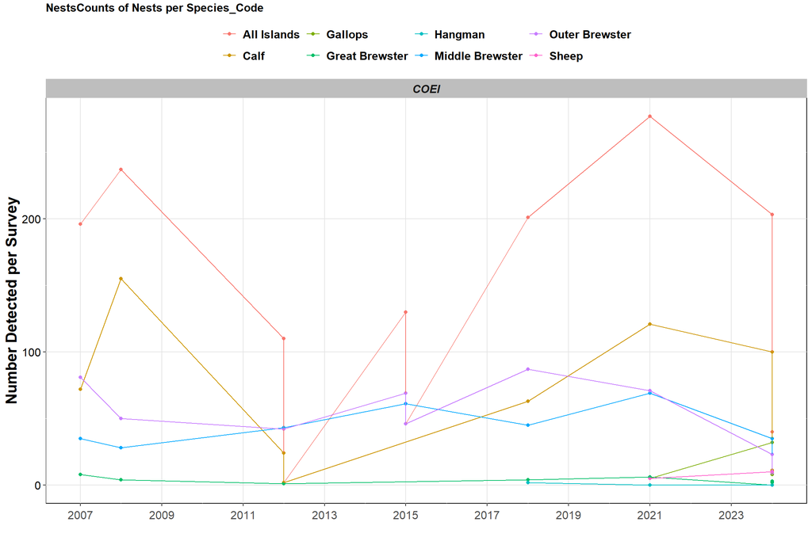

#### **Double-crested Cormorant (*Phalacrocorax auritus*)**

##### Current year (2025)

[1] “No ground-based nest surveys were collected during 2025”

##### Counts over time

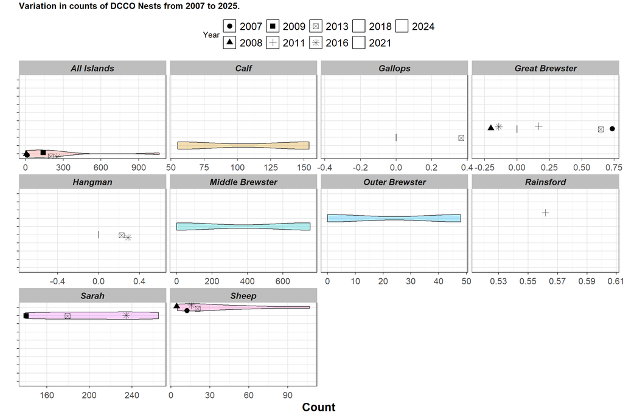

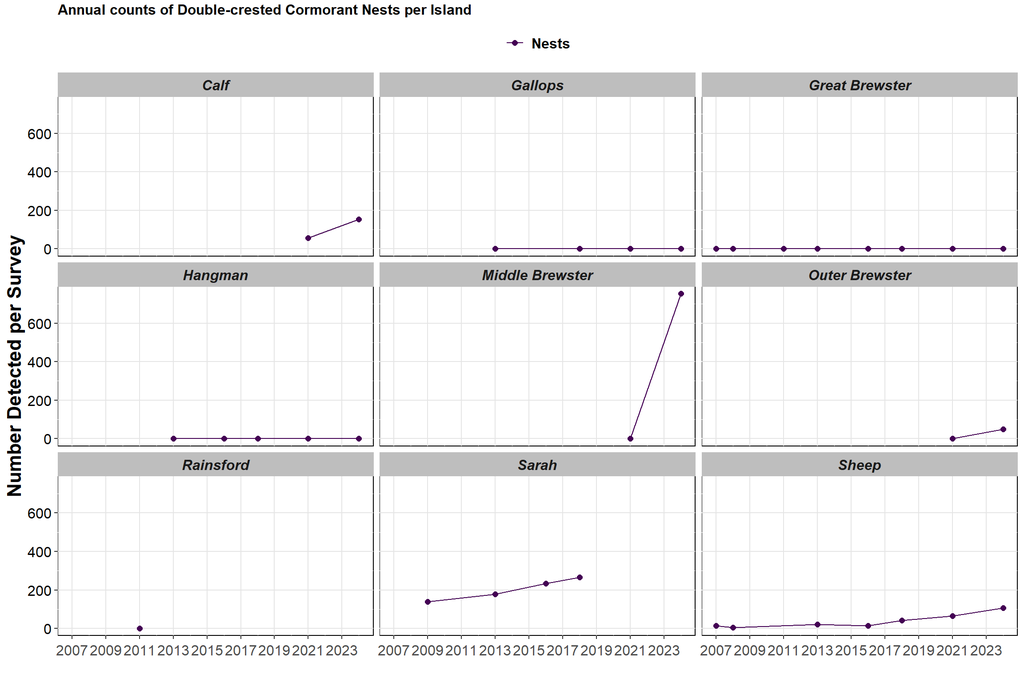

#### **Great Black-backed Gull (*Larus marinus*)**

##### Current year (2025)

[1] “No ground-based nest surveys were collected during 2025”

##### Counts over time

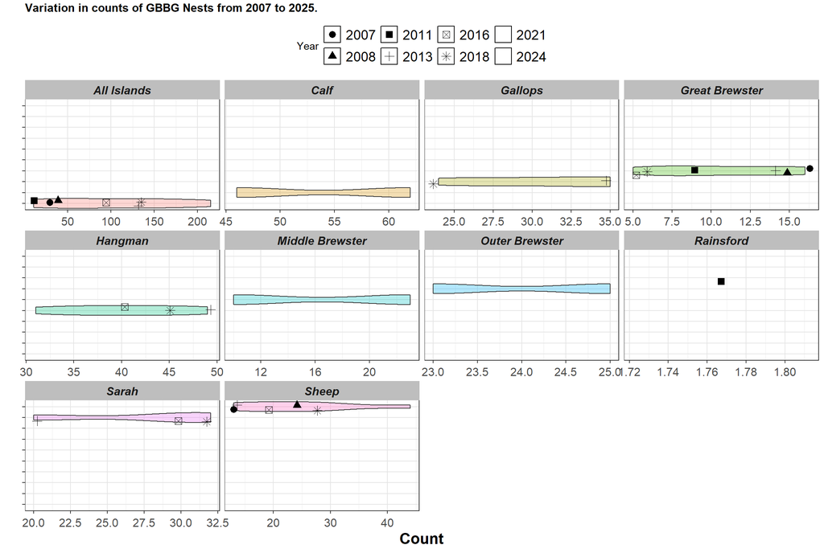

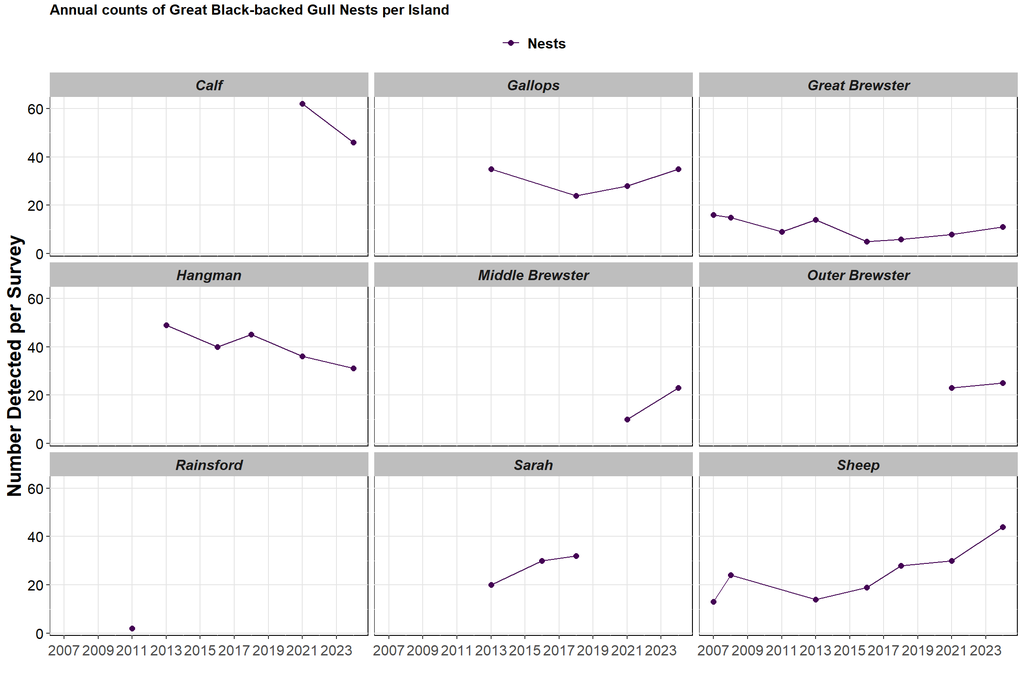

#### **Herring Gull (*Larus argentatus*)**

##### Current year (2025)

[1] “No ground-based nest surveys were collected during 2025”

##### Counts over time

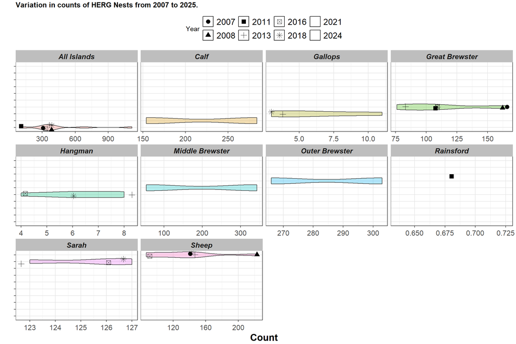

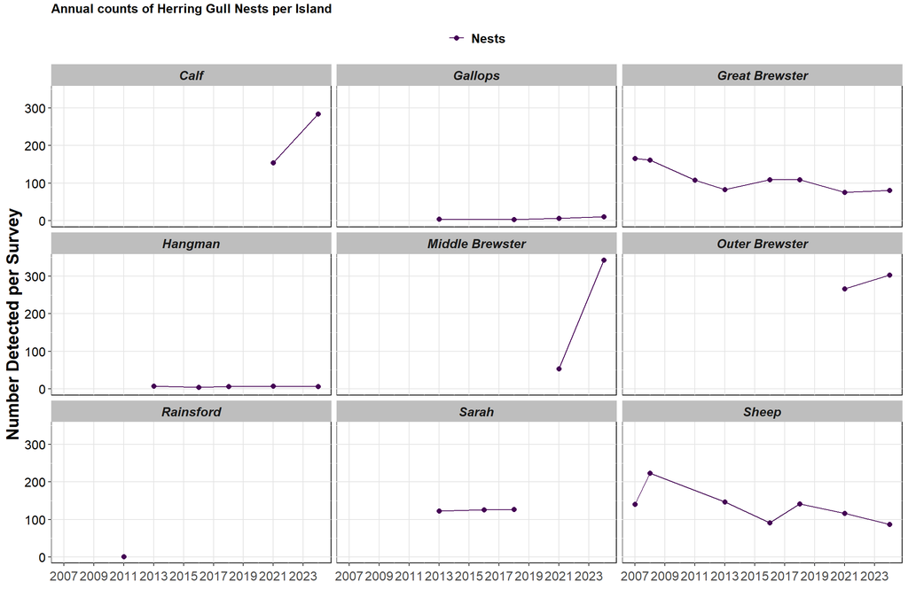

#### **Black-crowned night Heron (*Nycticorax nycticorax*)**

##### Current year (2025)

[1] “No ground-based nest surveys were collected during 2025”

##### Counts over time

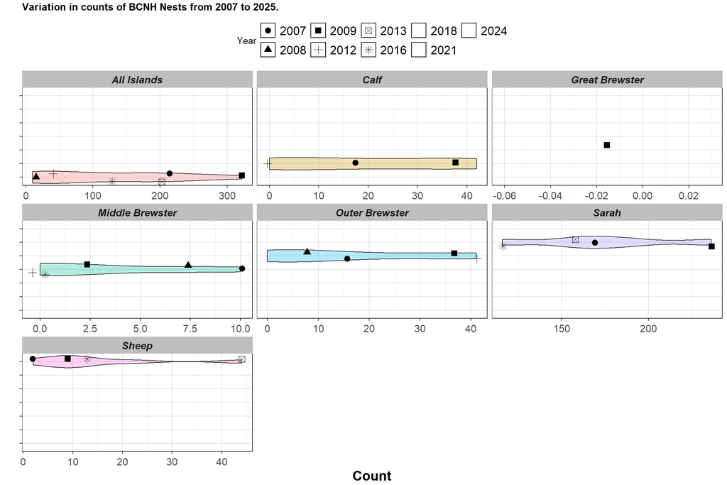

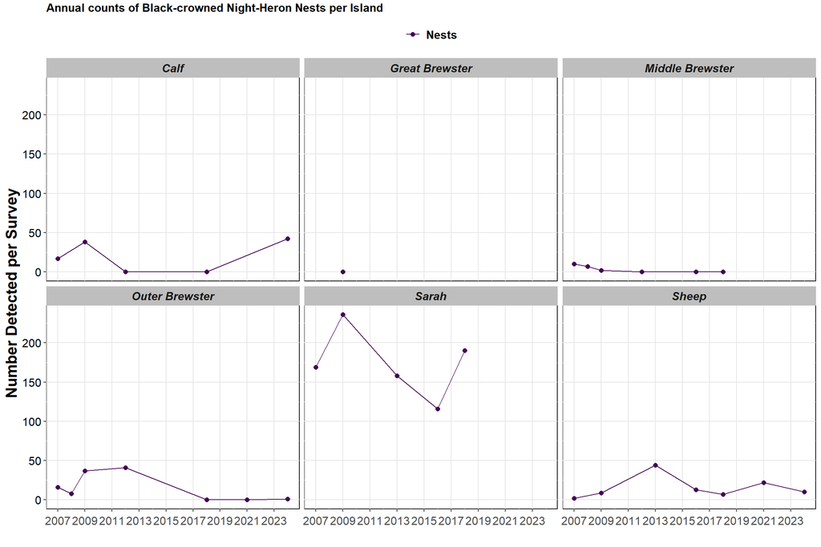

#### **Glossy Ibis (*Plegadis falcinellus*)**

##### Current year (2025)

[1] “No ground-based nest surveys were collected during 2025”

##### Counts over time

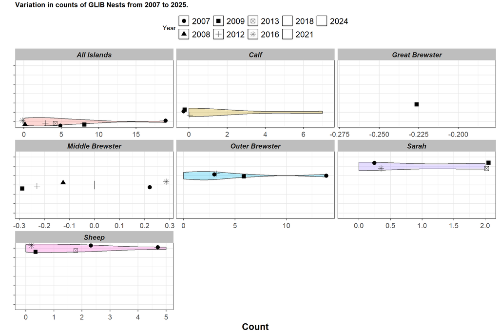

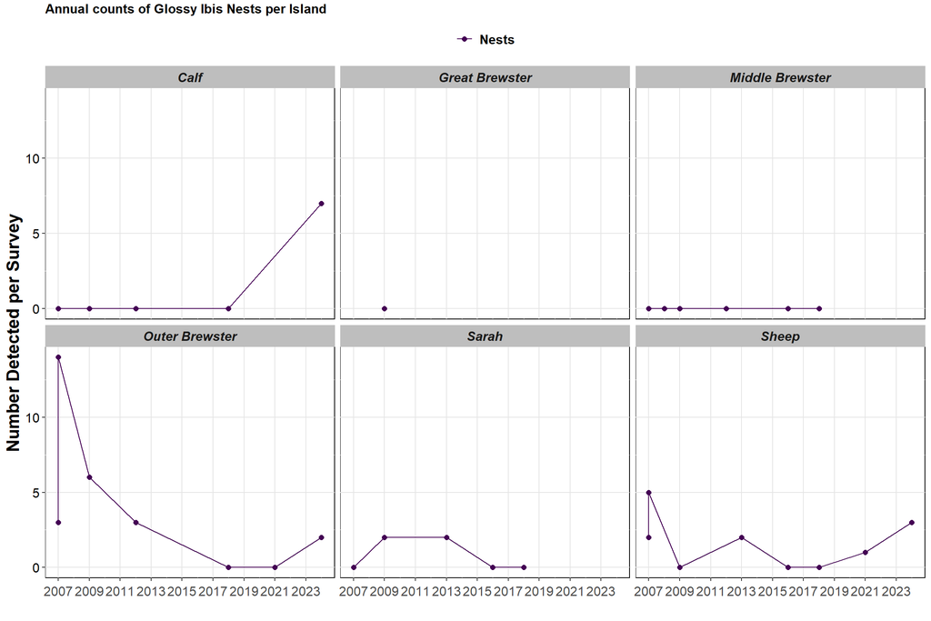

#### **Great Egret (*Ardea alba*)**

##### Current year (2025)

[1] “No ground-based nest surveys were collected during 2025”

##### Counts over time

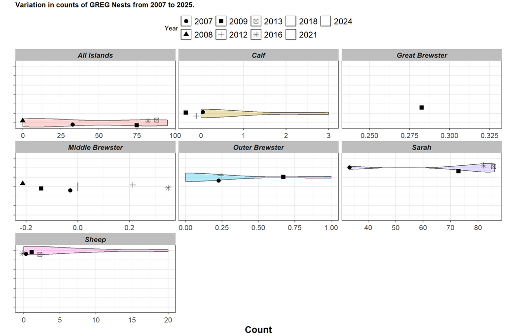

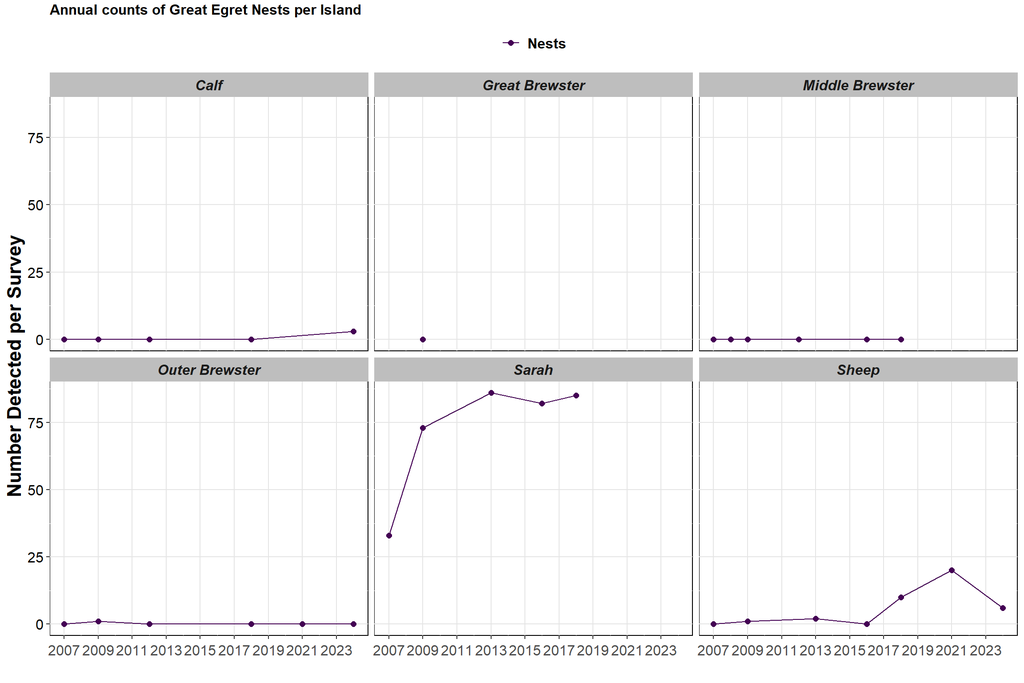